# Rent modelling in Munich: solution

Matteo Fasiolo

2025-05-27

1. Load data, plot it and fit a basic GAM:

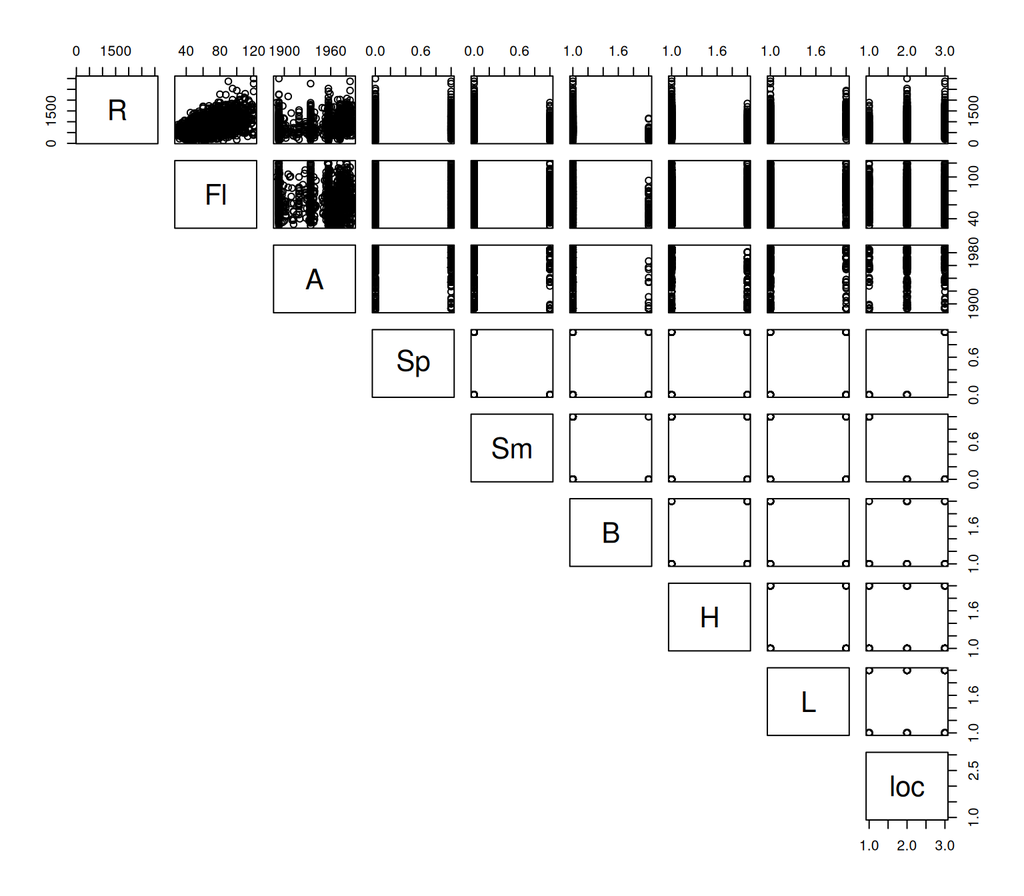

```r
library(testGam)
library(mgcViz)
data("munich_rent")

pairs(munich_rent, lower.panel = NULL)
```

```r
fit1 <- gamV(R ~ s(Fl) + s(A) + loc + B + H + L, data = munich_rent, aViz = list(nsim = 50))

summary(fit1)
```

```
##
## Family: gaussian
## Link function: identity
##
## Formula:
## R ~ s(Fl) + s(A) + loc + B + H + L
##
## Parametric coefficients:
##             Estimate Std. Error t value Pr(>|t|)
## (Intercept)   690.83      23.48  29.422  < 2e-16 ***
## loc2          140.03      24.42   5.735 1.13e-08 ***
## loc3          215.76      26.39   8.175 5.24e-16 ***
## B1           -136.38      47.77  -2.855  0.00435 **
## H1           -190.78      19.11  -9.985  < 2e-16 ***
## L1            156.96      25.19   6.230 5.69e-10 ***
## ---
## Signif. codes:  0 '***' 0.001 '**' 0.01 '*' 0.05 '.' 0.1 ' ' 1
##
## Approximate significance of smooth terms:
##         edf Ref.df     F p-value
## s(Fl) 1.475  1.814 317.5  <2e-16 ***
## s(A)  4.659  5.491  21.5  <2e-16 ***
## ---
## Signif. codes:  0 '***' 0.001 '**' 0.01 '*' 0.05 '.' 0.1 ' ' 1
##
## R-sq.(adj) =   0.38   Deviance explained = 38.3%
## -REML =  13988  Scale est. = 89128     n = 1969
```

Plot smooth effects:

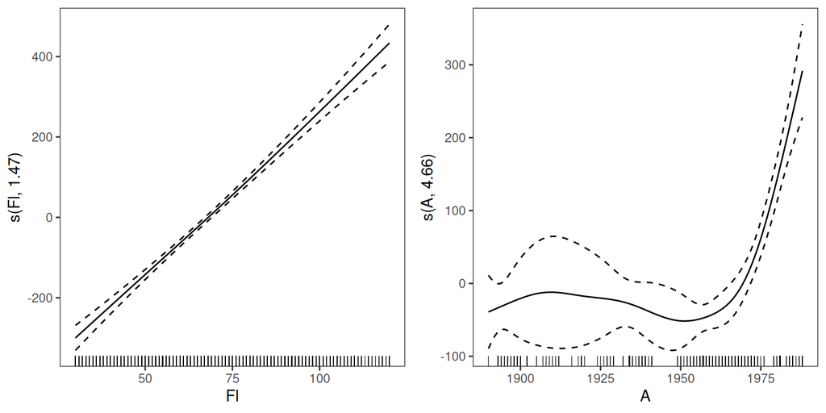

```r
print(plot(fit1), pages = 1)
```

2. Effect of `Fl` looks linear, and an interaction with location makes sense:

```r
fit2 <- gamV(R ~ Fl + Fl:loc + s(A) + loc + B + H + L, data = munich_rent, aViz = list(nsim = 50))

AIC(fit1, fit2)
```

```
##            df      AIC
## fit1 14.30521 28046.53
## fit2 14.94843 28024.61
```

We get lower AIC. See if coefficients make sense:

```r
summary(fit2)
```

```
##
## Family: gaussian
## Link function: identity
##
## Formula:
## R ~ Fl + Fl:loc + s(A) + loc + B + H + L
##
## Parametric coefficients:
##              Estimate Std. Error t value Pr(>|t|)
## (Intercept)  267.2004    75.4197   3.543 0.000405 ***
## Fl             6.2854     1.0457   6.010 2.20e-09 ***
## loc2          79.8459    80.4130   0.993 0.320858
## loc3         -71.2728    86.1725  -0.827 0.408284
## B1          -136.6895    47.5172  -2.877 0.004063 **
## H1          -191.6478    19.0000 -10.087  < 2e-16 ***
## L1           156.3601    25.0264   6.248 5.09e-10 ***
## Fl:loc2        0.8498     1.1180   0.760 0.447291
## Fl:loc3        4.1820     1.1961   3.496 0.000482 ***
## ---
## Signif. codes:  0 '***' 0.001 '**' 0.01 '*' 0.05 '.' 0.1 ' ' 1
##
## Approximate significance of smooth terms:
##       edf Ref.df    F p-value
## s(A) 4.62  5.448 22.1  <2e-16 ***
## ---
## Signif. codes:  0 '***' 0.001 '**' 0.01 '*' 0.05 '.' 0.1 ' ' 1
##
## R-sq.(adj) =  0.386   Deviance explained =   39%
## -REML =  13977  Scale est. = 88150     n = 1969
```

3. Looking at variance of residuals across covariates:

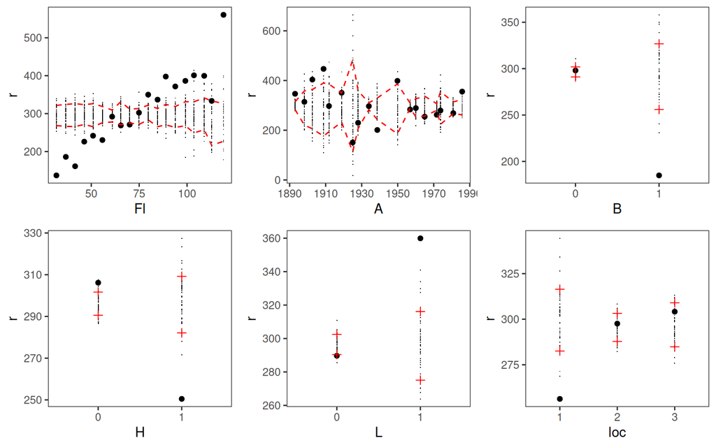

```r
pl <- check1D(fit2, list("Fl", "A", "B", "H", "L", "loc")) + l_gridCheck1D(gridFun = sd)
print(pl, pages = 1)
```

```r
fit3 <- gamV(list(R ~ Fl + Fl:loc + s(A) + loc + B + H + L,
                    ~ Fl + Fl:loc + s(A) + loc + B + H + L),
             data = munich_rent, family = gaulss, aViz = list(nsim = 50))

AIC(fit2, fit3)
```

```
##            df      AIC
## fit2 14.94843 28024.61
## fit3 27.75259 27730.51
```

Seems an improvements. Re-check residuals variance:

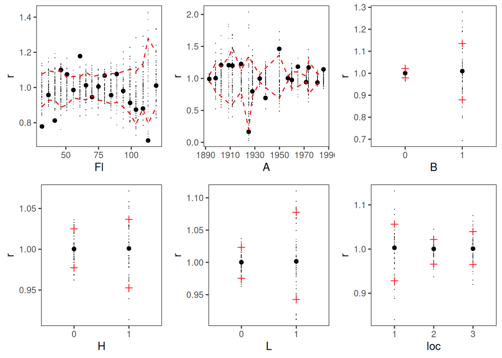

```r
pl <- check1D(fit3, list("Fl", "A", "B", "H", "L", "loc")) + l_gridCheck1D(gridFun = sd)
print(pl, pages = 1)
```

Looks better. Let’s look at the significance of the effects:

```r
summary(fit3)
```

```
##
## Family: gaulss
## Link function: identity logb
##
## Formula:
## R ~ Fl + Fl:loc + s(A) + loc + B + H + L
## ~Fl + Fl:loc + s(A) + loc + B + H + L
##
## Parametric coefficients:
##                 Estimate Std. Error z value Pr(>|z|)
## (Intercept)    2.901e+02  5.975e+01   4.854 1.21e-06 ***
## Fl             5.842e+00  9.060e-01   6.448 1.13e-10 ***
## loc2           5.637e+01  6.369e+01   0.885   0.3761
## loc3          -6.530e+01  6.867e+01  -0.951   0.3417
## B1            -1.355e+02  3.015e+01  -4.495 6.96e-06 ***
## H1            -1.743e+02  1.507e+01 -11.563  < 2e-16 ***
## L1             1.227e+02  2.679e+01   4.581 4.63e-06 ***
## Fl:loc2        1.262e+00  9.825e-01   1.285   0.1989
## Fl:loc3        4.183e+00  1.065e+00   3.927 8.61e-05 ***
## (Intercept).1  5.123e+00  1.789e-01  28.642  < 2e-16 ***
## Fl.1           6.085e-03  2.472e-03   2.462   0.0138 *
## loc2.1        -3.735e-01  1.924e-01  -1.941   0.0522 .
## loc3.1        -2.572e-01  2.098e-01  -1.226   0.2202
## B1.1          -2.089e-01  1.135e-01  -1.840   0.0657 .
## H1.1          -1.867e-01  4.343e-02  -4.300 1.71e-05 ***
## L1.1           9.422e-02  5.946e-02   1.585   0.1131
## Fl:loc2.1      7.275e-03  2.673e-03   2.722   0.0065 **
## Fl:loc3.1      5.568e-03  2.914e-03   1.911   0.0561 .
## ---
## Signif. codes:  0 '***' 0.001 '**' 0.01 '*' 0.05 '.' 0.1 ' ' 1
##
## Approximate significance of smooth terms:
##          edf Ref.df Chi.sq p-value
## s(A)   4.556  5.377 126.45 < 2e-16 ***
## s.1(A) 3.652  4.376  16.39 0.00261 **
## ---
## Signif. codes:  0 '***' 0.001 '**' 0.01 '*' 0.05 '.' 0.1 ' ' 1
##
## Deviance explained = 45.5%
## -REML =  13856  Scale est. = 1         n = 1969
```

Marginal effect of `loc` is not significant in the mean model, but we leave it there because the interaction `Fl:loc3` seems important.

4. Looking at residuals distribution:

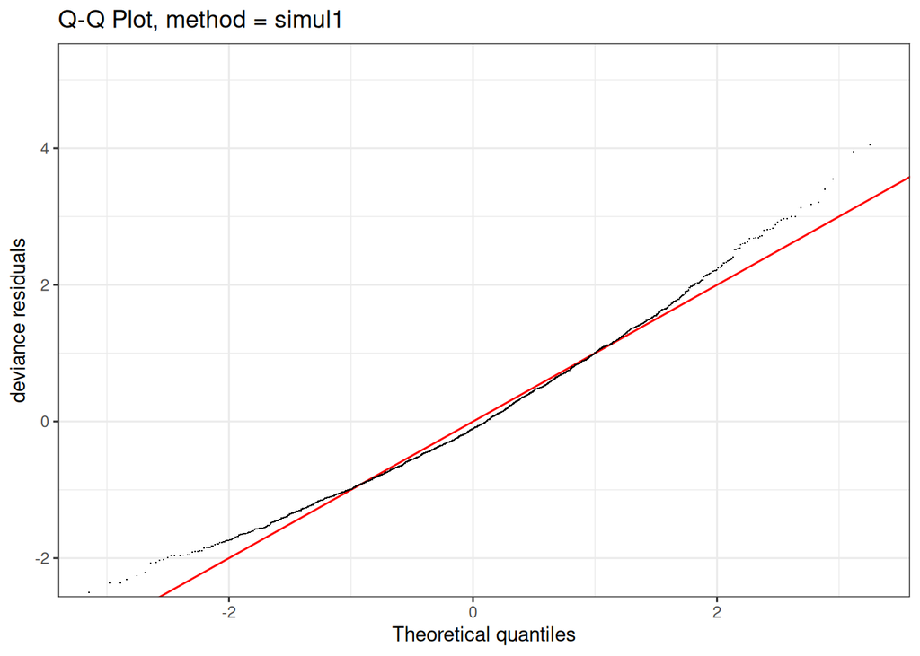

```r
qq(fit3)
```

It is skewed to the right. Let’s look at skewness as a function of the covariates:

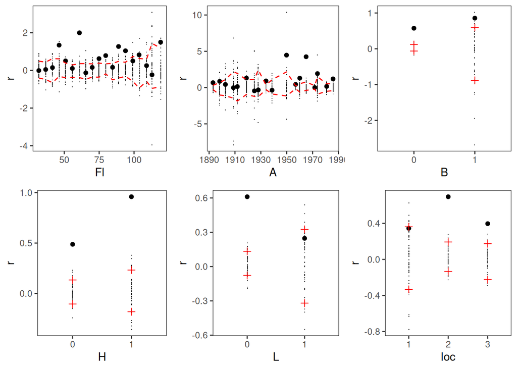

```r
pl <- check1D(fit3, list("Fl", "A", "B", "H", "L", "loc")) +
  l_gridCheck1D(gridFun = function(x) mean(x^3))
print(pl, pages = 1)
```

We adopt a `shash` models and include a model for skewness:

```r
fit4 <- gamV(list(R ~ Fl + Fl:loc + s(A) + loc + B + H + L,
                    ~ Fl + Fl:loc + s(A) + loc + B + H + L,
                    ~ Fl + Fl:loc + s(A) + loc + B + H + L,
                    ~ 1),
             data = munich_rent, family = shash, aViz = list(nsim = 50))

AIC(fit3, fit4)
```

```
##            df      AIC
## fit3 27.75259 27730.51
## fit4 40.21865 27618.83
```

Seems to improve things in terms of AIC. Lets re-check the skewness:

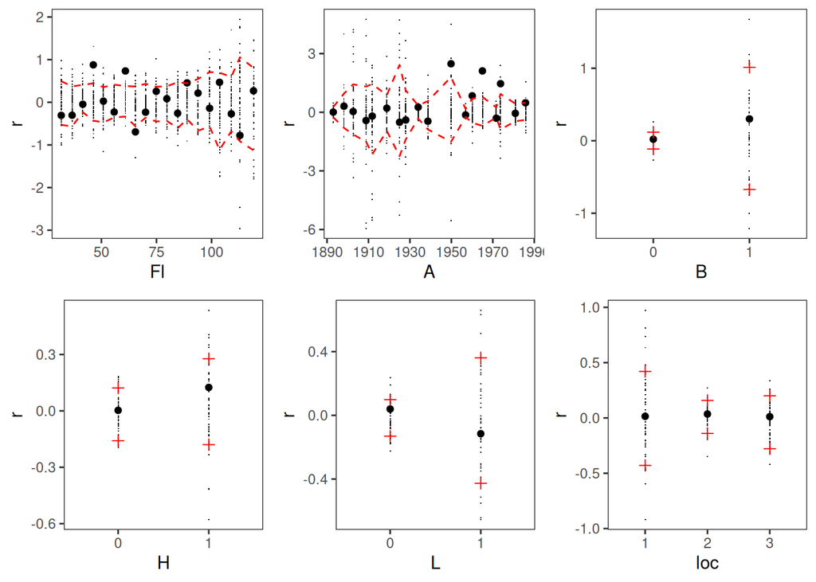

```r
pl <- check1D(fit4, list("Fl", "A", "B", "H", "L", "loc")) +
  l_gridCheck1D(gridFun = function(x) mean(x^3))
print(pl, pages = 1)
```

Looks better (notice that `l_gridCheck1D` by default uses 80% intervals). Final check:

```r
check(fit4)
```

```
##
## Method: REML   Optimizer: outer newton
## full convergence after 3 iterations.
## Gradient range [-0.006131815,-4.492794e-05]
## (score 13818.03 & scale 1).
## Hessian positive definite, eigenvalue range [0.1182023,1.587045].
## Model rank =  55 / 55
##
## Basis dimension (k) checking results. Low p-value (k-index<1) may
## indicate that k is too low, especially if edf is close to k'.
##
##          k'  edf k-index p-value
## s(A)   9.00 4.38     0.6  <2e-16 ***
## s.1(A) 9.00 4.14     0.6  <2e-16 ***
## s.2(A) 9.00 1.73     0.6  <2e-16 ***
## ---
## Signif. codes:  0 '***' 0.001 '**' 0.01 '*' 0.05 '.' 0.1 ' ' 1
```

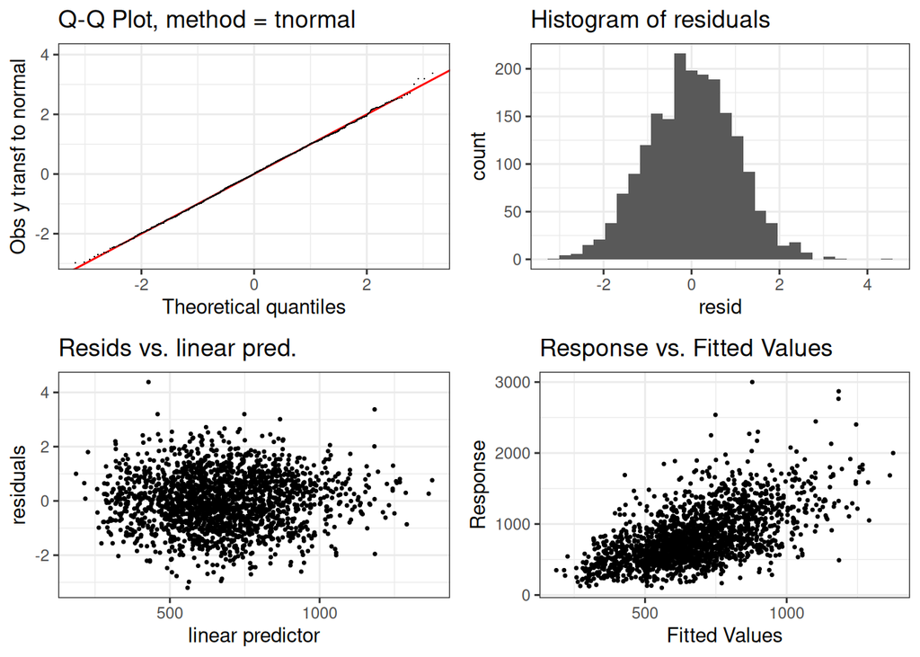

Residuals distribution looks good, these are the smooth effects:

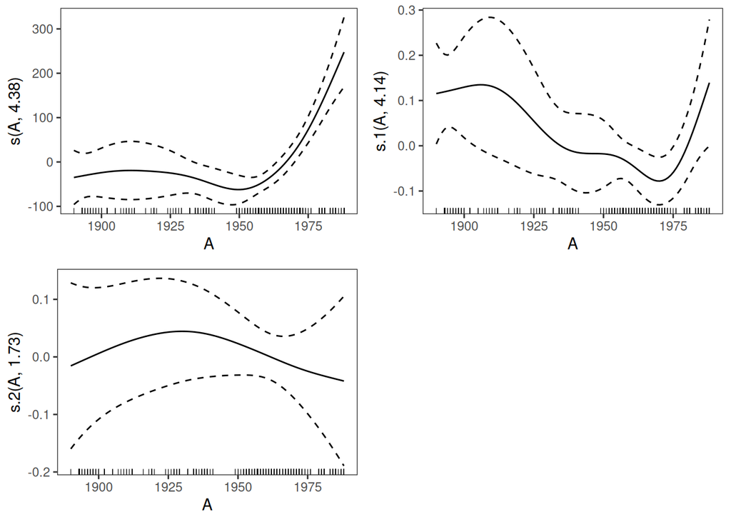

```r
print(plot(fit4), pages = 1)
```

and the output of `summary`:

```r
summary(fit4)
```

```
##
## Family: shash
## Link function: identity logeb identity identity
##
## Formula:
## R ~ Fl + Fl:loc + s(A) + loc + B + H + L
## ~Fl + Fl:loc + s(A) + loc + B + H + L
## ~Fl + Fl:loc + s(A) + loc + B + H + L
## ~1
##
## Parametric coefficients:
##                 Estimate Std. Error z value Pr(>|z|)
## (Intercept)    4.788e+02  9.974e+01   4.801 1.58e-06 ***
## Fl             1.615e+00  1.355e+00   1.192 0.233231
## loc2          -9.808e+01  1.062e+02  -0.924 0.355608
## loc3          -2.204e+02  1.150e+02  -1.917 0.055220 .
## B1            -8.344e+01  6.294e+01  -1.326 0.184923
## H1            -1.973e+02  2.803e+01  -7.040 1.93e-12 ***
## L1             7.652e+01  7.286e+01   1.050 0.293621
## Fl:loc2        2.794e+00  1.481e+00   1.887 0.059155 .
## Fl:loc3        6.395e+00  1.653e+00   3.870 0.000109 ***
## (Intercept).1  5.487e+00  2.323e-01  23.625  < 2e-16 ***
## Fl.1          -5.284e-04  3.605e-03  -0.147 0.883491
## loc2.1        -7.275e-01  2.445e-01  -2.975 0.002928 **
## loc3.1        -6.360e-01  2.548e-01  -2.497 0.012542 *
## B1.1          -1.738e-01  1.240e-01  -1.402 0.160997
## H1.1          -2.734e-01  5.328e-02  -5.130 2.89e-07 ***
## L1.1           9.682e-02  7.762e-02   1.247 0.212265
## Fl:loc2.1      1.269e-02  3.782e-03   3.355 0.000793 ***
## Fl:loc3.1      1.210e-02  3.877e-03   3.122 0.001799 **
## (Intercept).2 -6.967e-01  3.579e-01  -1.947 0.051547 .
## Fl.2           1.455e-02  5.214e-03   2.791 0.005250 **
## loc2.2         9.224e-01  3.773e-01   2.445 0.014504 *
## loc3.2         7.730e-01  4.019e-01   1.923 0.054440 .
## B1.2          -1.461e-01  2.471e-01  -0.591 0.554242
## H1.2           1.778e-01  9.130e-02   1.947 0.051522 .
## L1.2           4.658e-02  1.688e-01   0.276 0.782617
## Fl:loc2.2     -1.217e-02  5.426e-03  -2.244 0.024837 *
## Fl:loc3.2     -1.209e-02  5.703e-03  -2.119 0.034048 *
## (Intercept).3  2.480e-02  4.842e-02   0.512 0.608483
## ---
## Signif. codes:  0 '***' 0.001 '**' 0.01 '*' 0.05 '.' 0.1 ' ' 1
##
## Approximate significance of smooth terms:
##          edf Ref.df Chi.sq p-value
## s(A)   4.383  5.181  55.34 < 2e-16 ***
## s.1(A) 4.144  4.923  16.52 0.00372 **
## s.2(A) 1.731  2.114   0.68 0.66944
## ---
## Signif. codes:  0 '***' 0.001 '**' 0.01 '*' 0.05 '.' 0.1 ' ' 1
##
##
## -REML =  13818  Scale est. = 1         n = 1969
```